# Praca domowa nr 3

## Pytanie 2

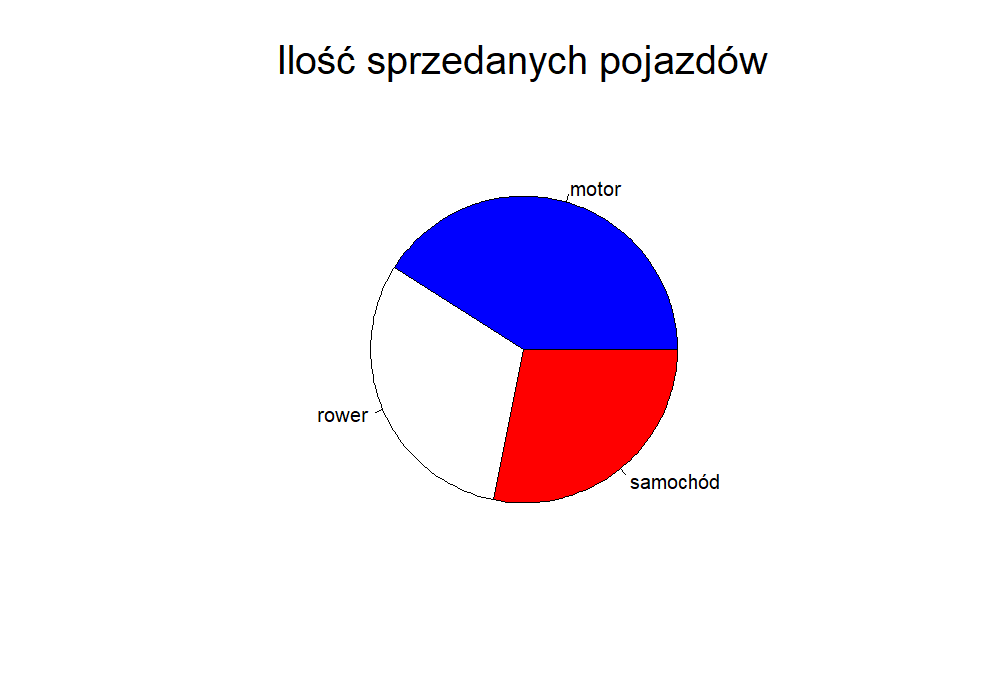

### Odpowiedzi:

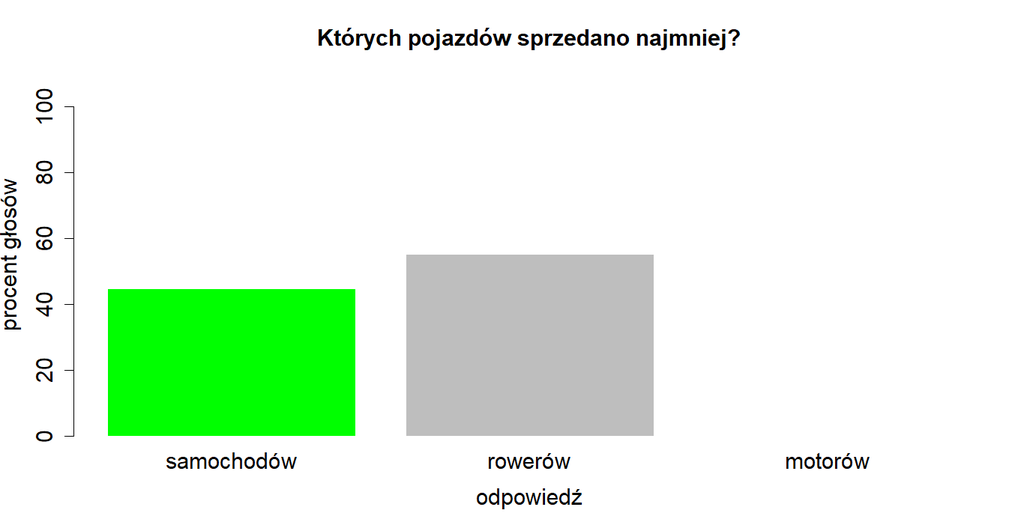

### Anazlia wyników - pytanie nr 2:

Wiemy, że wykresów kołowych należy unikać. To stwierdzenie potwierdzają wyniki tego badania. Różnica w liczbie sprzedanych rowerów równej 60 i liczbie sprzedanych samochodów równej 55 jest na wykresie kołowym prawie niezauważalna. Liczba motorów równa 80 rzeczywiście wydaje się być większa od poprzednich i pewnie dlatego nikt nie zaznaczył odpowiedzi - “motorów”. Prawidłową odpowiedź “samochodów” zaznaczyło mniej osób (44.8%) niż odpowiedź “rowerów” (55.2%).

## Pytanie 3

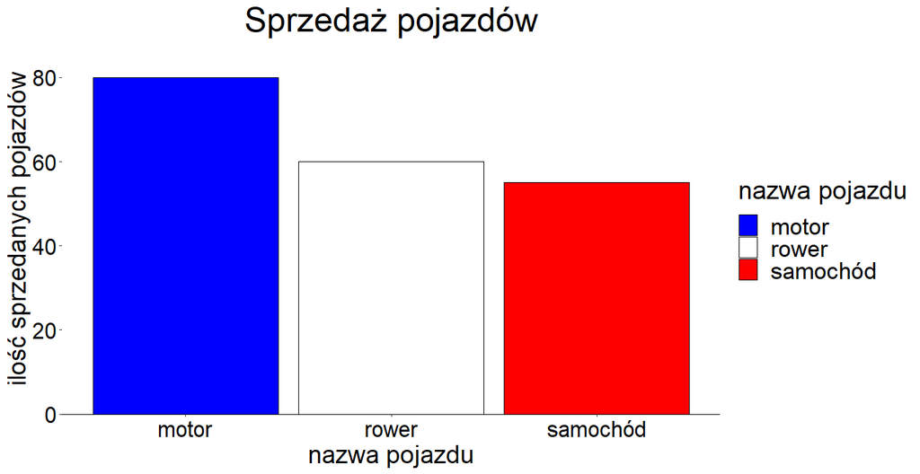

### Odpowiedzi:

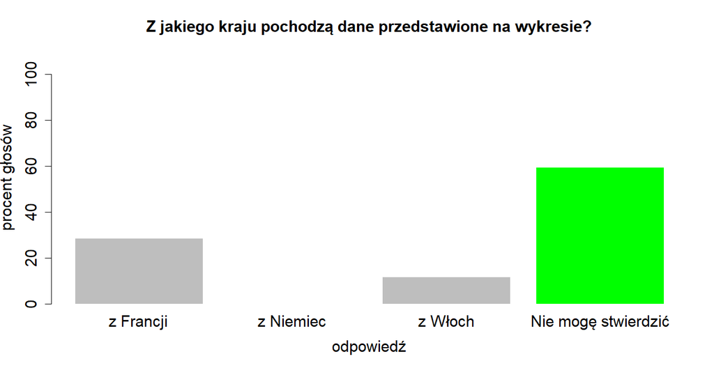

### Anazlia wyników - pytanie nr 3:

To pytanie miało sprawdzić, czy kolor wykresu może wpłynąć na jego interpretację. Kolory na wykresie układają się we flagę Francji. (podobną do flagi Włoch, co mogło zmylić 11,9% ankietowanych). Osoba niezajmująca się na co dzień wykresami, widząca pytanie “Z jakiego kraju pochodzą dane przedstawione na wykresie?” może bez namysłu stwierdzić, że skoro padło takie pytanie to zapewne chodzi o Francję. Dość dużo, bo (28,6%) ankietowanych uległo tej iluzji, mimo że mogli zaznaczyć prawidłową odpowiedź “Nie mogę stwierdzić”. Zaznaczyło ją 59,5% badanych, co pokazuje, że jednak większość osób nie wyciągnęła pochopnych wniosków na podstawie pewnych skojarzeń. Kolory na wykresie powinny być dobrane mądrze, tak aby pomóć, a nie utrudnić odczytać dane z wykresu.